# Anxiety Z-score linear model

Elena Eyre, PhD

2022-02-01

# 1. Loadings

## 1.1 Load packages

I uploaded packages of necessary functions to perform the calculations.

```r
knitr::opts_chunk$set(warning=FALSE)
package_to_load <- c("readxl", "dplyr", "ggplot2", "tidyr", "dplyr","RColorBrewer")
for (package in package_to_load) {
  require(package, character.only = T); packageVersion(package)
}
extra_to_load <- c("knitr","stringr", "stringi", "ggrepel","ggpubr", "ggbreak","reshape2","lme4","multcomp","car","lsmeans")
for (package in extra_to_load) {
  require(package, character.only = T); packageVersion(package)
}
```

```
## The 'lsmeans' package is now basically a front end for 'emmeans'.
## Users are encouraged to switch the rest of the way.
## See help('transition') for more information, including how to
## convert old 'lsmeans' objects and scripts to work with 'emmeans'.
```

```r
#rm(package_to_load, extra_to_load)
```

## 1.2 Load data

```r
df_original <- read_excel("220128_Analysis_adapted_Elena.xlsx")
anxiety_raw_dlb <- df_original[df_original$Experiment == "Dark Light Box",]
anxiety_raw_epm <- df_original[df_original$Experiment == "Elevate Pluse Maze",]
```

# 2. Previous to Z-score

Before the Z-score, we need to calculate control means and standard deviation.

For the Dark-light box experiment I make sure to select the center type:

```r
male_c_mean_dlb <- mean(anxiety_raw_dlb$Value[anxiety_raw_dlb$Sex == "M" & anxiety_raw_dlb$Diet == "CTRL"])
male_c_sd_dlb <- sd(anxiety_raw_dlb$Value[anxiety_raw_dlb$Sex == "M" & anxiety_raw_dlb$Diet == "CTRL"])
female_c_mean_dlb <- mean(anxiety_raw_dlb$Value[anxiety_raw_dlb$Sex == "F" & anxiety_raw_dlb$Diet == "CTRL"])
female_c_sd_dlb <- sd(anxiety_raw_dlb$Value[anxiety_raw_dlb$Sex == "F" & anxiety_raw_dlb$Diet == "CTRL"])
```

For the Elevated Plus Maze adulthood experiment:

```r
male_c_mean_epm <- mean(anxiety_raw_epm$Value[anxiety_raw_epm$Sex == "M" & anxiety_raw_epm$Diet == "CTRL"])
male_c_sd_epm <- sd(anxiety_raw_epm$Value[anxiety_raw_epm$Sex == "M" & anxiety_raw_epm$Diet == "CTRL"])
female_c_mean_epm <- mean(anxiety_raw_epm$Value[anxiety_raw_epm$Sex == "F" & anxiety_raw_epm$Diet == "CTRL"])
female_c_sd_epm <- sd(anxiety_raw_epm$Value[anxiety_raw_epm$Sex == "F" & anxiety_raw_epm$Diet == "CTRL"])
```

# 3. Calculate the Z-scores for each subset and experiment

To speed up the process, I created a function to calculate the z-score: zscore_gender(). It will return a vector of values corresponding to the z-scores associated to the subset we selected.

```r
zscore_gender <- function(data_frame,gender, mean_control,sd_control){
  d <- as.data.frame(data_frame[data_frame$Sex == gender & data_frame$Diet == "Emul",])
  d$z_score_male_of <-sapply(d$Value, function(x){
  (x - mean_control)/sd_control
  })
  return(d)
  }
```

For the Dark-light box experiment:

```r
z_score_male_dlb <-  zscore_gender(anxiety_raw_dlb, "M", male_c_mean_dlb, male_c_sd_dlb)
z_score_female_dlb <-  zscore_gender(anxiety_raw_dlb, "F", female_c_mean_dlb, female_c_sd_dlb)
```

For the Elevated Plus Maze adulthood (12-13 weeks) experiment:

```r
z_score_male_epm <-  zscore_gender(anxiety_raw_epm, "M", male_c_mean_epm, male_c_sd_epm)
z_score_female_epm <-  zscore_gender(anxiety_raw_epm, "F", female_c_mean_epm, female_c_sd_epm)
```

# 4. Visualize the Z-scores for each subset and experiment

In order to siplify the results, we join all the results into a new table, save it in a .txt file, and split it in order to define the data we want to show in a plot:

```r
df1 <- data.frame(rbind(z_score_male_dlb,z_score_female_dlb,z_score_male_epm,z_score_female_epm))
names(df1)[8] <- "Z_score"
kable(df1[1:4,],format = "simple",caption = "Reordered data table (with mothers and pups)") #%>% kable_styling(full_width = F, position = "left")%>%column_spec(1, bold = T)
```

Reordered data table (with mothers and pups)

| ID_Mouse | Sex | Treatment | Value | Experiment | Mother | Diet | Z_score |
| --- | --- | --- | --- | --- | --- | --- | --- |
| 7 | M | CO-Emul. | 29.90 | Dark Light Box | CO | Emul | -0.2074937 |
| 41 | M | CO-Emul. | 23.98 | Dark Light Box | CO | Emul | -0.7143834 |
| 19 | M | CO-Emul. | 32.23 | Dark Light Box | CO | Emul | -0.0079915 |
| 20 | M | CO-Emul. | 44.50 | Dark Light Box | CO | Emul | 1.0426059 |

```r
write.table(df1, "Values_gender_Zscores_all_anxiety_experiments_withMothers_and_diets.txt", sep = "|", dec = ".", row.names = F)

df2_dlb <- df1[df1$Experiment == "Dark Light Box", ]
df2_epm <- df1[df1$Experiment == "Elevate Pluse Maze", ]
```

Plots:

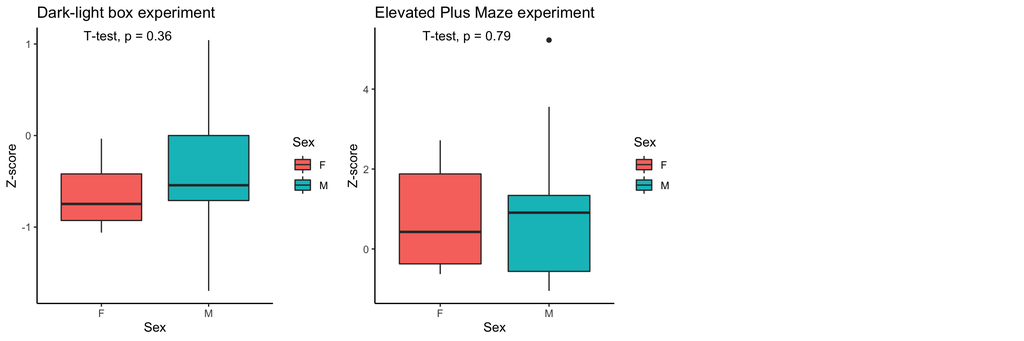

```r
set.seed(123) # Due to I apply a statistics analysis to extract the p-value from a t-test, I make sure to not bias it by adding this se.seed( ) function.
g2 <- ggplot(df2_dlb, aes(x=as.factor(Sex), y=Z_score)) + geom_boxplot(aes(x=as.factor(Sex),fill = as.factor(Sex))) + xlab("Sex") + ylab("Z-score") + ggtitle("Dark-light box experiment") + theme_classic()+ labs(fill= "Sex")+ stat_compare_means(method = "t.test")
g3 <- ggplot(df2_epm, aes(x=as.factor(Sex), y=Z_score)) + geom_boxplot(aes(x=as.factor(Sex),fill = as.factor(Sex))) + xlab("Sex") + ylab("Z-score") + ggtitle("Elevated Plus Maze experiment") + theme_classic()+ labs(fill= "Sex")+ stat_compare_means(method = "t.test")
ggarrange(g2, g3, ncol = 3, nrow = 1)
```

```r
pdf("Boxplots_gender_Zscores_anxiety_experiments_individually_MP.pdf", width = 5, height = 4)
g2
g3
dev.off()
```

```r
pdf("Boxplots_gender_Zscores_all_anxiety_experiments_MP.pdf", width = 11, height = 4)
ggarrange(g2, g3, ncol = 3, nrow = 1)
dev.off()
```

```r
##Before calculating the z-score:
g5 <- ggplot(anxiety_raw_dlb, aes(x=as.factor(Diet), y=Value)) + geom_boxplot(aes(x=as.factor(Diet),fill = as.factor(Sex))) + xlab("Diet") + ylab("Time spent in light (%)") + ggtitle("Dark-light box adulthood experiment") + theme_classic()+ labs(fill= "Sex")#+ stat_compare_means(method = "t.test")
g6 <- ggplot(anxiety_raw_epm, aes(x=as.factor(Diet), y=Value)) + geom_boxplot(aes(x=as.factor(Diet),fill = as.factor(Sex))) + xlab("Diet") + ylab("Time in zone (%)") + ggtitle("Elevated Plus Maze experiment") + theme_classic()+ labs(fill= "Sex")#+ stat_compare_means(method = "t.test")
pdf("Boxplots_gender_raw_data_anxiety_experiments_MP.pdf", width = 11, height = 4)
ggarrange(g5, g6, ncol = 3, nrow = 1)
dev.off()
```

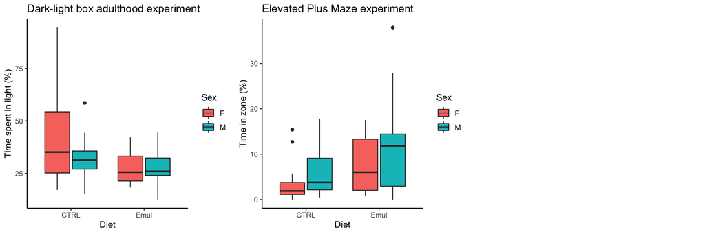

```r
ggarrange(g5, g6, ncol = 3, nrow = 1)
```

# 5. Anxiety Z-score for only Females vs Males

I explore the outcome if we take the Chow group as the corresponding control group, and we would like to compare only Gender, I develop another z-score formula:

$Anxiety~Score = (Z_DLB + Z_EPM) / Number~of~tests$

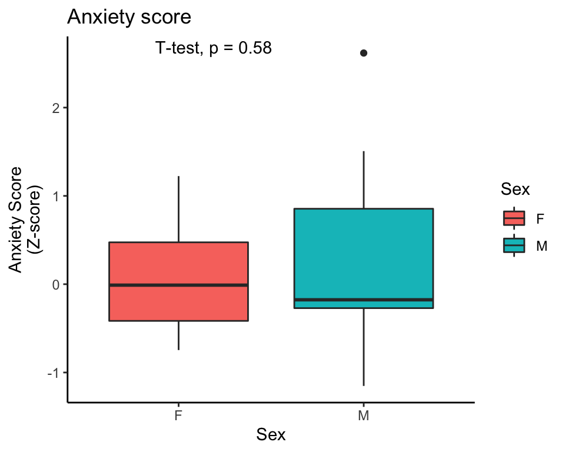

```r
df3m <- NULL
df3f <- NULL
df3m$Anx_Zscore <- (df1$Z_score[df1$Experiment == "Dark Light Box" & df1$Sex == "M"] + df1$Z_score[df1$Experiment == "Elevate Pluse Maze" & df1$Sex == "M"])/2
df3f$Anx_Zscore <- ( df1$Z_score[df1$Experiment == "Dark Light Box" & df1$Sex == "F"] + df1$Z_score[df1$Experiment == "Elevate Pluse Maze" & df1$Sex == "F"])/2
df3m$Sex <- "M"
df3f$Sex <- "F"
df3 <- as.data.frame(rbind(as.data.frame(df3m),as.data.frame(df3f)))
#df3 <- reshape2::melt(df3,variable.name = "Subsets",value.name = "Anx_Zscore")
write.table(df3, "Zscores_all_anxiety_experiments.txt", sep = "|", dec = ".", row.names = F)
g7 <- ggplot(df3, aes(x=as.factor(Sex), y=Anx_Zscore)) + geom_boxplot(aes(x=as.factor(Sex),fill = as.factor(Sex))) + xlab("Sex") + ylab("Anxiety Score\n(Z-score)") + ggtitle("Anxiety score") + theme_classic()+ labs(fill= "Sex")+ stat_compare_means(method = "t.test")
g7
```

```r
pdf("Boxplots_gender_anxiety_final_score_experiments.pdf", width = 5, height = 4)
g7
dev.off()
```

# 6. Anxiety Z-score for Emul vs CT (and Gender)

Since the authors of the paper take the males group and the corresponding control group, and we would like to compare only diets, I develop another z-score formula:

```r
zscore <- function(data_frame,mean_control,sd_control){
  d <- as.data.frame(data_frame)
  d$z_score_male_of <-sapply(d$Value, function(x){
  (x - mean_control)/sd_control
  })
  }
```

Here I apply the formula using the males group and the corresponding control group, to each experiment:

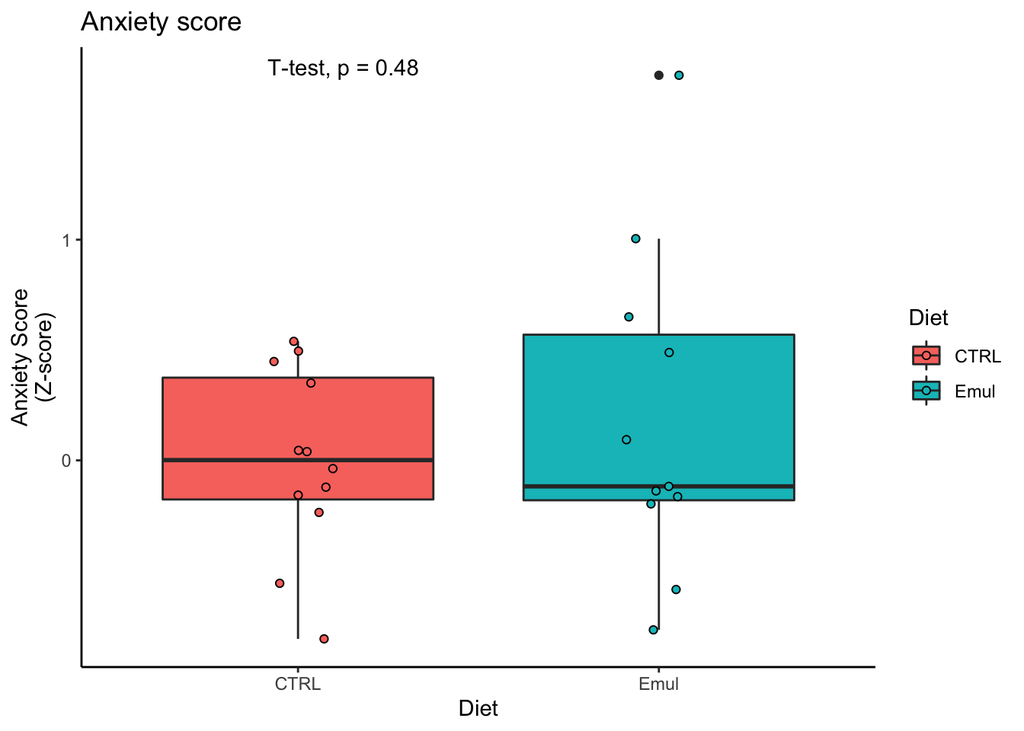

```r
anxiety_raw_dlb$zscores <- zscore(anxiety_raw_dlb,male_c_mean_dlb,male_c_sd_dlb)
anxiety_raw_epm$zscores <- zscore(anxiety_raw_epm,male_c_mean_epm,male_c_sd_epm)

df5 <- rbind(anxiety_raw_dlb,anxiety_raw_epm)
df5 <- df5[df5$Sex != "F",]
df6 <- data.frame(DLB = df5[df5$Experiment =="Dark Light Box", ],EPM = df5[df5$Experiment =="Elevate Pluse Maze", ])
df6$Anx_zscore <- (df6$DLB.zscores + df6$EPM.zscores)/3
df6 <- df6[,c(2,3,6,7,17)]
colnames(df6) <- c("Sex","Treatment","Mother", "Diet","Anx_zscore")

ggplot(df6, aes(x=as.factor(Diet), y=Anx_zscore)) + geom_boxplot(mapping= aes(x=as.factor(Diet), y=Anx_zscore,fill=as.factor(Diet)))+ xlab("Diet") + ylab("Anxiety Score\n(Z-score)")+labs(fill="Diet") + ggtitle("Anxiety score") +geom_point(pch = 21, position = position_jitterdodge(), aes(x=as.factor(Diet),fill = as.factor(Diet)))+ theme_classic()+ stat_compare_means(aes(x=as.factor(Diet), y=Anx_zscore),method = "t.test")
```

```r
write.table(df6, "Anxiety_Zscores_only_males.txt", sep = "|", dec = ".", row.names = F)
```

Then, I apply the formula using the both, males and females group and the corresponding control group, to each experiment: the final outcome suggest there is no significant changes.

$Value = (1 | Mother) + Sex + Diet + Sex*Diet$

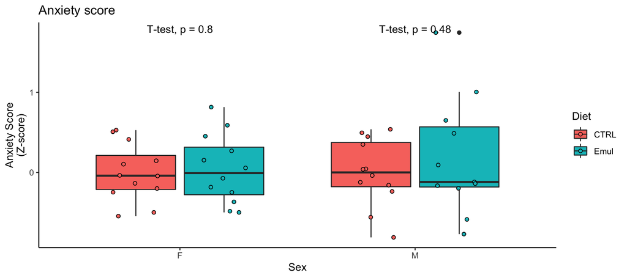

```r
anxiety_raw_dlb$zscores <- ifelse(anxiety_raw_dlb$Sex == "M", zscore(anxiety_raw_dlb,male_c_mean_dlb,male_c_sd_dlb), zscore(anxiety_raw_dlb,female_c_mean_dlb,female_c_sd_dlb))
anxiety_raw_epm$zscores <- ifelse(anxiety_raw_epm$Sex == "M", zscore(anxiety_raw_epm,male_c_mean_epm,male_c_sd_epm), zscore(anxiety_raw_epm,female_c_mean_epm,female_c_sd_epm))

df5 <- rbind(anxiety_raw_dlb,anxiety_raw_epm)
df6 <- data.frame(DLB = df5[df5$Experiment =="Dark Light Box", ],EPM = df5[df5$Experiment =="Elevate Pluse Maze", ])
df6$Anx_zscore <- (df6$DLB.zscores + df6$EPM.zscores)/3
df6 <- df6[,c(2,3,6,7,17)]
colnames(df6) <- c("Sex","Treatment","Mother", "Diet","Anx_zscore")
write.table(df6, "Anxiety_Zscores_both_malesAndFemales.txt", sep = "|", dec = ".", row.names = F)

ggplot(df6, aes(x=as.factor(Sex), y=Anx_zscore)) + geom_boxplot(mapping= aes(x=as.factor(Sex), y=Anx_zscore,fill=as.factor(Diet)))+scale_y_continuous() + xlab("Sex") + ylab("Anxiety Score\n(Z-score)")+labs(fill="Diet") + ggtitle("Anxiety score") +geom_point(pch = 21, position = position_jitterdodge(), aes(x=as.factor(Sex),fill = as.factor(Diet)))+ theme_classic()+stat_compare_means(aes(x=as.factor(Sex), y=Anx_zscore,fill = as.factor(Diet)),method = "t.test")
```

```r
fit_mf3 <- lmer(Anx_zscore ~ (1 | Mother) + Sex +  Diet + Sex*Diet, data=df6)
Anova(fit_mf3, test ="Chisq", type="III", error.estimate = "deviance")
```

```
## Analysis of Deviance Table (Type III Wald chisquare tests)
##
## Response: Anx_zscore
##              Chisq Df Pr(>Chisq)
## (Intercept) 0.0000  1     1.0000
## Sex         0.0000  1     1.0000
## Diet        0.0451  1     0.8319
## Sex:Diet    0.2182  1     0.6404
```

```r
print(summary(fit_mf3))
```

```
## Linear mixed model fit by REML ['lmerMod']
## Formula: Anx_zscore ~ (1 | Mother) + Sex + Diet + Sex * Diet
##    Data: df6
##
## REML criterion at convergence: 69.4
##
## Scaled residuals:
##     Min      1Q  Median      3Q     Max
## -1.6896 -0.6911 -0.1953  0.5796  3.0325
##
## Random effects:
##  Groups   Name        Variance Std.Dev.
##  Mother   (Intercept) 0.04589  0.2142
##  Residual             0.22457  0.4739
## Number of obs: 47, groups:  Mother, 2
##
## Fixed effects:
##                 Estimate Std. Error t value
## (Intercept)   -3.998e-16  2.041e-01   0.000
## SexM           1.782e-16  1.935e-01   0.000
## DietEmul       4.108e-02  1.935e-01   0.212
## SexM:DietEmul  1.293e-01  2.768e-01   0.467
##
## Correlation of Fixed Effects:
##             (Intr) SexM   DitEml
## SexM        -0.474
## DietEmul    -0.474  0.500
## SexM:DitEml  0.331 -0.699 -0.699
```

```r
tuk <- glht(fit_mf3, limfct = mcp(Diet = "Tukey")) # To obtain the details of the single variable
print(summary(tuk))
```

```
##
##   Simultaneous Tests for General Linear Hypotheses
##
## Fit: lmer(formula = Anx_zscore ~ (1 | Mother) + Sex + Diet + Sex *
##     Diet, data = df6)
##
## Linear Hypotheses:
##                      Estimate Std. Error z value Pr(>|z|)
## (Intercept) == 0   -3.998e-16  2.041e-01   0.000    1.000
## SexM == 0           1.782e-16  1.935e-01   0.000    1.000
## DietEmul == 0       4.108e-02  1.935e-01   0.212    0.998
## SexM:DietEmul == 0  1.293e-01  2.768e-01   0.467    0.966
## (Adjusted p values reported -- single-step method)
```

```r
tuk <- glht(fit_mf3, limfct = mcp(Sex = "Tukey")) # To obtain the details of the single variable
print(summary(tuk))
```

```
##
##   Simultaneous Tests for General Linear Hypotheses
##
## Fit: lmer(formula = Anx_zscore ~ (1 | Mother) + Sex + Diet + Sex *
##     Diet, data = df6)
##
## Linear Hypotheses:
##                      Estimate Std. Error z value Pr(>|z|)
## (Intercept) == 0   -3.998e-16  2.041e-01   0.000    1.000
## SexM == 0           1.782e-16  1.935e-01   0.000    1.000
## DietEmul == 0       4.108e-02  1.935e-01   0.212    0.998
## SexM:DietEmul == 0  1.293e-01  2.768e-01   0.467    0.966
## (Adjusted p values reported -- single-step method)
```

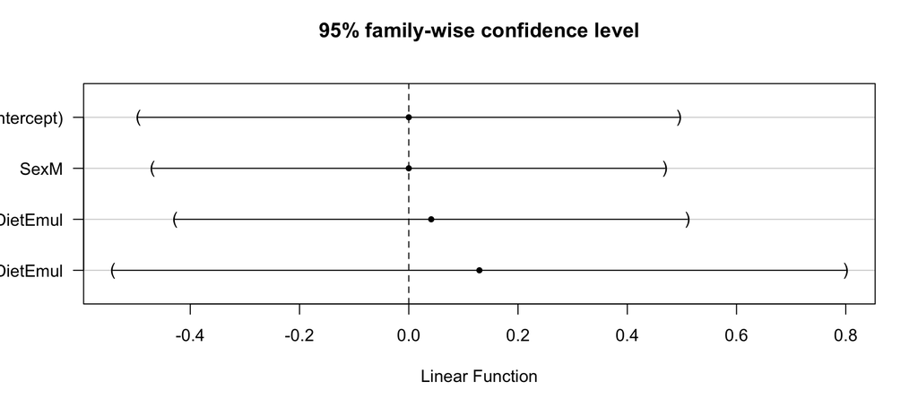

```r
plot(confint(tuk))
```

```r
kable(as.data.frame(lsmeans(fit_mf3, pairwise~Sex*Diet, adjust="tukey")$contrasts)[,c(1,6)], caption = "Pairwise comparisons")
```

Pairwise comparisons

| contrast | p.value |
| --- | --- |
| F CTRL - M CTRL | 1.0000000 |
| F CTRL - F Emul | 0.9965635 |
| F CTRL - M Emul | 0.8249847 |
| M CTRL - F Emul | 0.9965635 |
| M CTRL - M Emul | 0.8249847 |
| F Emul - M Emul | 0.9138969 |